# Project #2

# **Question 3, What trends emerge when plotting the data?**

To answer my question, I will first generate a plot using matplotlib to show the sum of each year and the "Total Result" column, from the not 0 dataframe generated above.

[figure not shown]

|  | Country | Total Result |
| --- | --- | --- |
| 0 | Afghanistan | 74904.0 |
| 1 | Africa | 372798.0 |
| 2 | Albania | 188.0 |
| 3 | Algeria | 4991.0 |
| 4 | Americas | 68274.0 |
| ... | ... | ... |
| 201 | Vietnam | 93831.0 |
| 202 | Western Pacific | 450333.0 |
| 204 | Yemen | 37298.0 |
| 206 | Zambia | 15765.0 |
| 207 | Zimbabwe | 1796.0 |

154 rows × 2 columns

```python
not_0 = df[df['Total Result'] > 0][['Country','Total Result']]
TRnot0 = not_0['Total Result']
Cnot0 = list(not_0['Country'])

fig,ax = plt.subplots(nrows=1, ncols=1)

ax.bar = (Cnot0,TRnot0)
plt.xlabel('Countries',fontsize=12)
plt.ylabel('Sum of Cases',fontsize=12)
plt.xticks(rotation='vertical',fontsize=15)
plt.title("Total Number of Paralytic Poliomyelitis Cases in Each Country (1980-2020) ", fontsize = 15)

ax.grid()
plt.show()
not_0
```

```python
sum2 = df['Total Result'] #y-axis
countries = list(df['Country']) #x-axis
fig,ax = plt.subplots(nrows=1,ncols=1,figsize=(120,40))

ax.bar(countries,sum2,align='edge')

plt.xlabel('countries',fontsize=60)
plt.ylabel('Sum of Cases',fontsize=60)
plt.xticks(rotation='vertical',fontsize=20)
plt.title("Total Number of Paralytic Poliomyelitis Cases Each Year (1980-2020)", fontsize = 80)

ax.grid()
plt.show()
```

[figure not shown]

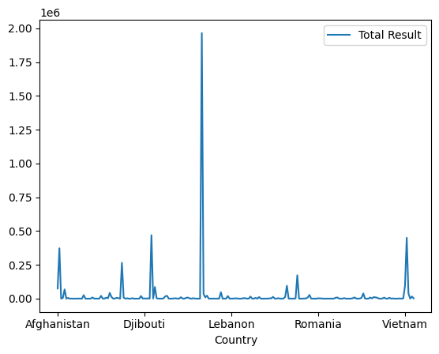

```python
df.plot(x='Country',y='Total Result')
```

```python
list(sum)
```

```
[596197.0,
 640766.0,
 529844.0,
 382312.0,
 325220.0,
 378014.0,
 316050.0,
 347270.0,
 306477.0,
 205452.0,
 183885.0,
 117858.0,
 131948.0,
 115108.0,
 85484.0,
 75082.0,
 7699.0,
 8374.0,
 8789.0,
 12117.0,
 5939.0,
 1220.0,
 3931.0,
 1827.0,
 2800.0,
 4930.0,
 3713.0,
 2088.0,
 2088.0,
 3226.0,
 3201.0,
 3921.0,
 1652.0,
 651.0,
 1130.0,
 939.0,
 276.0,
 99.0,
 262.0,
 406.0,
 1305.0,
 3744.0,
 4821206.0]
```

# **Question 4, Where was Polio the most dominant in the 1980s?**

Since the modern data collection of paralytic poliomyelitis begins in 1980, from what I have been able to find, it is important to clarify where the disease was the most dominant when cases were initially being tallied.

To answer this, I will create a new column in the data frame to account for all of the cases in the first 5 years of data spanning from 1980-1984.

```python
df['1980-1984'] = df[['1980','1981','1982','1983','1984']].sum(axis=1)
df[['Country','1980-1984']]
```

|  | Country | 1980-1984 |
| --- | --- | --- |
| 0 | Afghanistan | 39550.0 |
| 1 | Africa | 134736.0 |
| 2 | Albania | 14.0 |
| 3 | Algeria | 3787.0 |
| 4 | Americas | 49553.0 |
| ... | ... | ... |
| 202 | Western Pacific | 292474.0 |
| 204 | Yemen | 20286.0 |
| 205 | Yugoslavia | 0.0 |
| 206 | Zambia | 9149.0 |
| 207 | Zimbabwe | 532.0 |

206 rows × 2 columns

Next I will sort the newly generate column and output the top 10 countries.

```python
oldtop10 = df.sort_values('1980-1984',ascending = False)[0:12].copy()
oldtop10[['Country','1980-1984']]
```

|  | Country | 1980-1984 |
| --- | --- | --- |
| 83 | India | 917924.0 |
| 202 | Western Pacific | 292474.0 |
| 54 | Eastern Mediterranean | 272167.0 |
| 37 | China | 208110.0 |
| 1 | Africa | 134736.0 |
| 138 | Pakistan | 86212.0 |
| 56 | Egypt | 52577.0 |
| 4 | Americas | 49553.0 |
| 0 | Afghanistan | 39550.0 |
| 201 | Vietnam | 38843.0 |
| 177 | Sudan | 31423.0 |
| 30 | Cambodia | 21546.0 |

# **Question 4 Answer:**

The regions of the world that recieved the most cases is quite obvious upon one glance at the table generated above, as countries in the middle east area and spanning across Asia, although India was subjected to many cases more than any of the other countries.

# **Question 5, Where does the disease still exist in the world?**

To answer this, I will generate a table to show the countries that have reported the most cases in the last 5 years.

First I have to make a new column in the table that takes the sum across the last 5 years for all of the countries in the dataset.

Next I will sum the values from the past 5 years into a new column in the dataframe using the .sum(axis=1) function since axis = 1 speacifies to sum the columns together.

```python
df['2016-2020'] = df[['2016','2017','2018','2019','2020']].sum(axis=1)
df['2016-2020']
```

```
0       489.0
1      1626.0
2         0.0
3         0.0
4         0.0
        ...
202      96.0
204      35.0
205       0.0
206       2.0
207       0.0
Name: 2016-2020, Length: 206, dtype: float64
```

Next, I will take the top 10 from the new column to find out where the polio virus is still prevelent using the .sort_values() function.

```python
newtop10 = df.sort_values('2016-2020',ascending = False)[0:13].copy()
newtop10[['Country','2016-2020']]
```

|  | Country | 2016-2020 |
| --- | --- | --- |
| 1 | Africa | 1626.0 |
| 54 | Eastern Mediterranean | 1183.0 |
| 0 | Afghanistan | 489.0 |
| 138 | Pakistan | 476.0 |
| 48 | Democratic Republic of Congo | 324.0 |
| 35 | Chad | 214.0 |
| 6 | Angola | 159.0 |
| 28 | Burkina Faso | 131.0 |
| 43 | Cote d'Ivoire | 128.0 |
| 111 | Mali | 104.0 |
| 173 | South Sudan | 100.0 |
| 202 | Western Pacific | 96.0 |
| 75 | Guinea | 88.0 |

[figure not shown]

```python
ntotal = newtop10[['2016-2020']]
#newtop10.set_index('Country',inplace=True)
countries = list(newtop10.index)

fig,ax = plt.subplots(nrows=1, ncols=1)

ax.bar = (countries,ntotal)
plt.xlabel('Countries',fontsize=12)
plt.ylabel('Sum of Cases',fontsize=12)
plt.xticks(rotation='vertical',fontsize=15)
plt.title("Countries with the Highest Number of Polio Cases (2016-2020) ", fontsize = 15)

ax.grid()
plt.show()
```

Note: I generated the top 13 results as three of them are not specifically one country.